```python
# Render our plots inline
%matplotlib inline

import pandas as pd
import matplotlib.pyplot as plt

pd.set_option('display.mpl_style', 'default') # Make the graphs a bit prettier
plt.rcParams['figure.figsize'] = (15, 5)
```

# 1.1 读取csv格式文件

用`read_csv`函数可以读取csv数据，默认数据之间是用逗号分隔开的。

有时候数据集并不是这样的啊，咱们看看比较完整的读数据参数设定。

```python
broken_df = pd.read_csv('../data/bikes.csv')
```

```python
# 看看前3行
broken_df[:3]
```

|  | Date;Berri 1;Br�beuf (donn�es non disponibles);C�te-Sainte-Catherine;Maisonneuve 1;Maisonneuve 2;du Parc;Pierre-Dupuy;Rachel1;St-Urbain (donn�es non disponibles) |
| --- | --- |
| 0 | 01/01/2012;35;;0;38;51;26;10;16; |
| 1 | 02/01/2012;83;;1;68;153;53;6;43; |
| 2 | 03/01/2012;135;;2;104;248;89;3;58; |

3 rows × 1 columns

一脸懵逼了，读得完全不对~~ `read_csv`有相应的参数需要我们设定一下，比如对于上面的数据，我们希望：

- 数据分隔符设定为`;`
- 编码格式设定为 `'latin1'` (默认 `'utf8'`)
- 解析一下 'Date' 字段
- 按照 'Date' 字段(日期)排序

```python
fixed_df = pd.read_csv('../data/bikes.csv', sep=';', encoding='latin1', parse_dates=['Date'], dayfirst=True, index_col='Date')
fixed_df[:3]
```

| Date | Berri 1 | Brébeuf (données non disponibles) | Côte-Sainte-Catherine | Maisonneuve 1 | Maisonneuve 2 | du Parc | Pierre-Dupuy | Rachel1 | St-Urbain (données non disponibles) |
| --- | --- | --- | --- | --- | --- | --- | --- | --- | --- |
| 2012-01-01 | 35 | NaN | 0 | 38 | 51 | 26 | 10 | 16 | NaN |
| 2012-01-02 | 83 | NaN | 1 | 68 | 153 | 53 | 6 | 43 | NaN |
| 2012-01-03 | 135 | NaN | 2 | 104 | 248 | 89 | 3 | 58 | NaN |

3 rows × 9 columns

# 1.2 筛选某些列

用pandas读取完CSV文件呢, 我们会得到一个叫做`DataFrame`的对象，由行和列组成类似上面的excel(说废话的感觉)。可以像下面这样通过列名取出其中的某一列。

```python
fixed_df['Berri 1']
```

```
Date
2012-01-01     35
2012-01-02     83
2012-01-03    135
2012-01-04    144
2012-01-05    197
2012-01-06    146
2012-01-07     98
2012-01-08     95
2012-01-09    244
2012-01-10    397
2012-01-11    273
2012-01-12    157
2012-01-13     75
2012-01-14     32
2012-01-15     54
...
2012-10-22    3650
2012-10-23    4177
2012-10-24    3744
2012-10-25    3735
2012-10-26    4290
2012-10-27    1857
2012-10-28    1310
2012-10-29    2919
2012-10-30    2887
2012-10-31    2634
2012-11-01    2405
2012-11-02    1582
2012-11-03     844
2012-11-04     966
2012-11-05    2247
Name: Berri 1, Length: 310
```

# 1.3 画一下某一列？

直接在这一列尾部加上 `.plot()` 就可以了，就喜欢这么简单粗暴！！

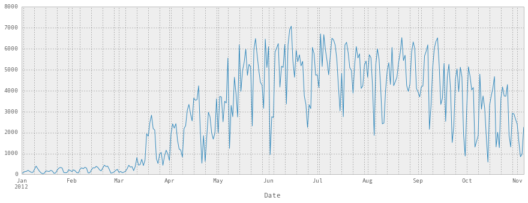

```python
fixed_df['Berri 1'].plot()
```

你问我如果想画多列怎么办？ 就像下面这样就可以啦，你告诉我它，“我需要画整个dataframe的图！！！”，然后它就画了，恩。

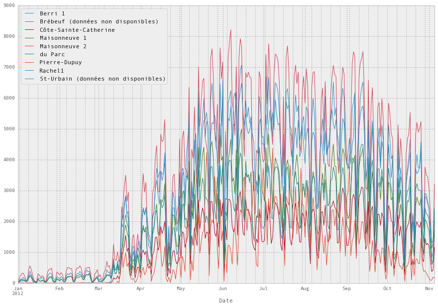

```python
fixed_df.plot(figsize=(15, 10))
```

# 1.4 一句话串读取和绘图

好吧，其实我的意思就是你可以直接一口气读完数据然后画出来，恩:

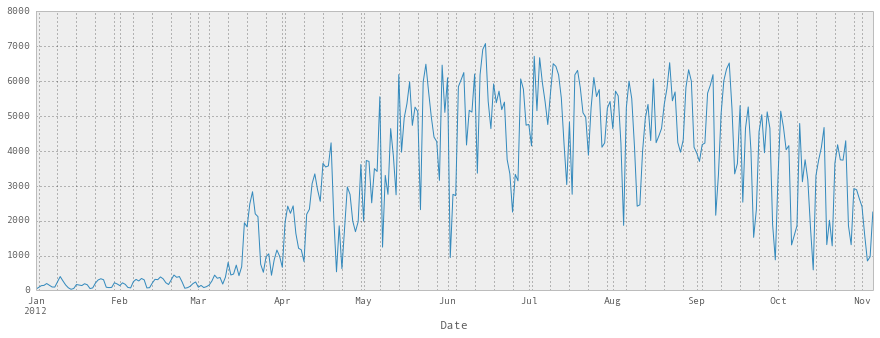

```python
df = pd.read_csv('../data/bikes.csv', sep=';', encoding='latin1', parse_dates=['Date'], dayfirst=True, index_col='Date')
df['Berri 1'].plot()
```